# Investigating SoapDeNovo-Trans K51 Human Filtered Assembly

Gerry Tonkin-Hill

31/8/2015

Load input files

```r
EIC_processed_contigs <- read.delim("/home/users/allstaff/tonkin-hill.g/assembly_testing/ComparisonForManuscript/SoapDeNovo_withHumanFilter/EICv2/analytics_output.txt")
ECS_processed_contigs <- read.delim("/home/users/allstaff/tonkin-hill.g/assembly_testing/ComparisonForManuscript/SoapDeNovo_withHumanFilter/ECS/analytics_output.txt")
CS2_processed_contigs <- read.delim("/home/users/allstaff/tonkin-hill.g/assembly_testing/ComparisonForManuscript/SoapDeNovo_withHumanFilter/CS2/analytics_output.txt")
```

```r
library(ggplot2)
library(reshape)
plot_contigs <- function(blastData, length_filt, identity_filt, var_gene_lengths){
  # blastData <-EIC_processed_contigs
  #first filter out unmatched contigs and convert types
  blastData <- data.frame(subset(blastData, sequence.id != '-'))
  blastData$alignment.length <-as.numeric(as.character(blastData$alignment.length))
  blastData$s..start <-as.numeric(as.character(blastData$s..start))
  blastData$s..end <-as.numeric(as.character(blastData$s..end))
  blastData$q..start <-as.numeric(as.character(blastData$q..start))
  blastData$q..end <-as.numeric(as.character(blastData$q..end))
  blastData$percent.identity <-as.numeric(as.character(blastData$percent.identity))

  #now filter out hits we aren't interested in
  #blastData <- subset(blastData, alignment.length > length_filt) #throw away contigs less than 3 reads ~ length residues long
  #blastData <- subset(blastData, alignment.length > 800) #throw away contigs less than 3 reads ~ length residues long
  #blastData <- subset(blastData, percent.identity > identity_filt) #throw away alignments that share less than x%

  #now split into seperate data frames for each database
  var_hits <- subset(blastData, grepl("blastHits_Full_var_rask2010*",data.base.name))
  var_hits <- subset(var_hits, alignment.length > length_filt) #throw away contigs less than 3 reads ~ length residues long
  var_hits <- subset(var_hits, percent.identity > identity_filt) #throw away alignments that share less than x%

  #var_hits <-subset(var_hits, (sequence.id == 'IT4var04') | (sequence.id == 'IT4var08'))
  human_hits <- subset(blastData, grepl("blastHits_human_reference*",data.base.name))
  Pf3D7_hits <- subset(blastData, grepl("blastHits_Pf3D7_reference*",data.base.name))
  Pf3D7_hits <- subset(Pf3D7_hits, alignment.length > 100) #throw away contigs less than 3 reads ~ length residues long
  Pf3D7_hits <- subset(Pf3D7_hits, percent.identity > 85) #throw away alignments that share less than x%

  #filter out human and Pf3D7 contigs that aren't matched to any var genes
  var_contigs <- unique(var_hits$contig.id)
  human_hits <- subset(human_hits, contig.id %in% var_contigs)
  Pf3D7_hits <- subset(Pf3D7_hits, contig.id %in% var_contigs)

  #now annoying stuff so ggplot doesnt get upset (give each contig a different height?)
  ydf <- data.frame(contig.id=unique(var_hits$contig.id) , y=as.numeric(factor(unique(var_hits$contig.id))))
  var_hits <- merge(var_hits, ydf, by="contig.id")
  human_hits <- merge(human_hits, ydf, by="contig.id")
  Pf3D7_hits <- merge(Pf3D7_hits, ydf, by="contig.id")


  #Now generate the underlying contigs (full length)
  contig <- var_hits
  contig$s..start <- contig$s..start - contig$q..start
  contig$s..end <- contig$s..start+contig$contig.length

   #now change the Pf3D7 sequence to be in terms of the var reference VERY HACKY
  diff <- data.frame(contig.id=contig$contig.id, diff=contig$s..start, diff_seq=contig$sequence.id)
  diff <- subset(diff, !duplicated(contig.id))
  diff <- merge(diff, Pf3D7_hits, by="contig.id")

  Pf3D7_hits$s..start <- diff$diff  + Pf3D7_hits$q..start
  Pf3D7_hits$s..end <- diff$diff + Pf3D7_hits$q..end
  Pf3D7_hits$sequence.id <- diff$diff_seq

  #get the gene lengths from rask data
  var_gene_lengths <- var_gene_lengths[var_gene_lengths$sequence.id %in% intersect(var_gene_lengths$sequence.id, contig$sequence.id),]



  gg <- ggplot(data=contig, aes(xmin = s..start, xmax = s..end, ymin = y, ymax = y+1, fill=factor(contig.id))) + geom_rect( alpha=0.4)
  gg <- gg + geom_rect(data=var_hits, aes(xmin = s..start, xmax = s..end, ymin = y, ymax = y+1, fill=factor(contig.id), labels = rpk))
  #gg <- gg + geom_rect(data=Pf3D7_hits, aes(xmin = s..start, xmax = s..end, ymin = y, ymax = y+1), color="black", alpha=0.5)

  gg <- gg + geom_text(data=var_hits, aes(x=s..start+(s..end-s..start)/2, y=y+(y+1-y)/2, label=paste(contig.id,rpk, sep=" ")), size=8)
  gg <- gg + geom_vline(data = var_gene_lengths, aes(xintercept = gene.length))
  gg <- gg + facet_wrap(~sequence.id)
  gg <- gg + xlab("location on reference sequence")
  gg <- gg + ylab("") + scale_y_continuous(breaks=NULL)
  gg <- gg + mytheme()
  print(gg)
  #paste(percent.identity,mismatches,gap.opens, sep=" ")
  rpk_counts <- aggregate(. ~ sequence.id, data=var_hits, sum)
  rpk_counts <- rpk_counts[,(names(rpk_counts) %in% c('sequence.id','rpk'))]
  names(rpk_counts) <- c("var.name", "contig.count")
  return(rpk_counts)
}
```

Function to calculate redundancy

```r
library(data.table)
library(IRanges)
library(GenomicRanges)
redundancy <- function(blastData, length_filt, var_gene_lengths, identity_filt=97){
#   blastData <-CS2_processed_contigs
  #first filter out unmatched contigs and convert types
  blastData <- data.frame(subset(blastData, sequence.id != '-'))
  blastData$alignment.length <- as.numeric(as.character(blastData$alignment.length))
  blastData$s..start <- as.numeric(as.character(blastData$s..start))
  blastData$s..end <- as.numeric(as.character(blastData$s..end))
  blastData$q..start <- as.numeric(as.character(blastData$q..start))
  blastData$q..end <- as.numeric(as.character(blastData$q..end))
  blastData$percent.identity <- as.numeric(as.character(blastData$percent.identity))
  blastData$alignment.length <- as.numeric(as.character(blastData$alignment.length))
  blastData$bit.score <- as.numeric(as.character(blastData$bit.score))

  #now split into seperate data frames for each database
  var_hits <- subset(blastData, grepl("blastHits_Full_var_rask2010*",data.base.name))
  var_hits <- subset(var_hits, alignment.length > length_filt) #throw away contigs less than 3 reads ~ length residues long
  var_hits <- subset(var_hits, percent.identity > identity_filt) #throw away alignments that share less than x%

  #var_hits <-subset(var_hits, (sequence.id == 'IT4var04') | (sequence.id == 'IT4var08'))
  human_hits <- subset(blastData, grepl("blastHits_human_reference*",data.base.name))
  Pf3D7_hits <- subset(blastData, grepl("blastHits_Pf3D7_reference*",data.base.name))
  Pf3D7_hits <- subset(Pf3D7_hits, alignment.length > 100) #throw away contigs less than 3 reads ~ length residues long
  Pf3D7_hits <- subset(Pf3D7_hits, percent.identity > 85) #throw away alignments that share less than x%

  #filter out human and Pf3D7 contigs that aren't matched to any var genes
  var_contigs <- unique(var_hits$contig.id)
  human_hits <- subset(human_hits, contig.id %in% var_contigs)
  Pf3D7_hits <- subset(Pf3D7_hits, contig.id %in% var_contigs)

  #sort var hit by name then bit score
  var_hits <- var_hits[with(var_hits, order(contig.id, bit.score, decreasing=TRUE)), ]
  var_hits <- droplevels(var_hits)
  #remove duplicated contigs which have overlapping query regions.

  VH <- as.data.table(var_hits)
  VH$q..start <- VH$q..start+250
  VH$q..end <- VH$q..end-250
  VH[,group := {
      ir <-  IRanges(q..start, q..end);
      subjectHits(findOverlaps(ir, reduce(ir), minoverlap=0))
      },by=contig.id]
  VH$q..start <- VH$q..start-250
  VH$q..end <- VH$q..end+250



  VH <- data.frame(VH)
  VH <- VH[!duplicated(VH[,colnames(VH) %in% c('contig.id', 'group')]),]
  VH$group <- NULL

  total.alignment <- sum(VH$alignment.length)

  gr = GRanges(VH$sequence.id,
            IRanges(VH$s..start, VH$s..end),
                strand="*")
  re <- reduce(gr)
  total.coverage <- sum(width(ranges(re)))

  redundancy <- total.alignment/total.coverage
  return(redundancy)
}
```

Load more data

```r
#expression data
var_expressions_mike <- read.csv("/wehisan/home/allstaff/t/tonkin-hill.g/assembly_testing/counts/var_expressions_mike.csv")

#read count data
read_counts_against_IT4_genes <- read.csv("/wehisan/home/allstaff/t/tonkin-hill.g/assembly_testing/counts/read_counts_against_IT4_genes.csv")
CS2_read_counts <- data.frame('var name'=read_counts_against_IT4_genes$CS2, 'counts'=read_counts_against_IT4_genes$counts)
ECS_read_counts <- data.frame('var name'=read_counts_against_IT4_genes$ECS, 'counts'=read_counts_against_IT4_genes$counts.1)
EIC_read_counts <- data.frame('var name'=read_counts_against_IT4_genes$EIC, 'counts'=read_counts_against_IT4_genes$counts.2)

#gene length data
var_gene_lengths <- read.delim("/wehisan/home/allstaff/t/tonkin-hill.g/find_var_genes/assemble_var/data/var_rask_lengths.txt", header=F)
colnames(var_gene_lengths) <- c("sequence.id", "gene.length")
var_gene_lengths <- data.frame(var_gene_lengths)
```

Lets look at a plot of the contigs for ECS.

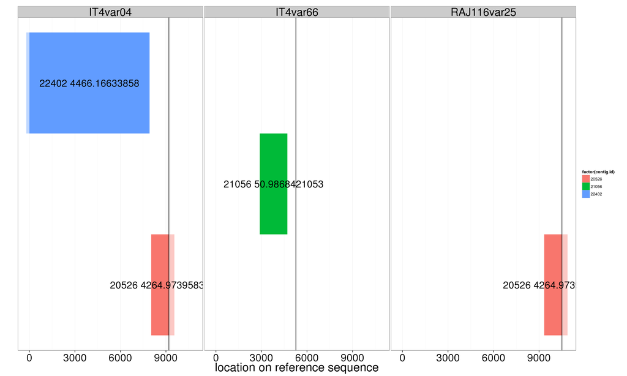

```r
contig_counts <- plot_contigs(ECS_processed_contigs, 800, 95, var_gene_lengths)
```

```r
redundancy(ECS_processed_contigs, 800, var_gene_lengths, 95)
```

```
## [1] 1
```

For the expression plots I first aligned all the reads for each sample onto all the IT4var genes. This is reffered to as ‘whole gene count’. I then aligned all the reads for each sample onto the contigs output by our assembly pipeline. This is reffered to as ‘contig count’. Finally expression count are the 2exp-deltadeltaCt numbers from the quantification assay. All these counts are normalised and then plotted on a log10 scale. Thus each point on the y-axis can be interpreted as 0.1% of the total for that count type and that sample.

plot expression for ECS

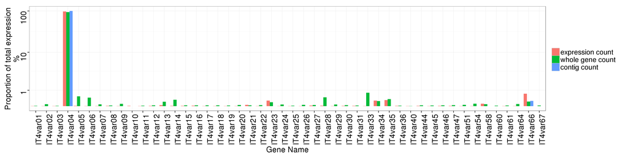

```r
ecs_df <- merge(var_expressions_mike, ECS_read_counts, by='var.name')
ecs_df <- ecs_df[,!(names(ecs_df) %in% c('CS2','EIC'))]
ecs_df$counts <- ecs_df$counts/sum(ecs_df$counts)
ecs_df$ECS <- ecs_df$ECS/sum(ecs_df$ECS)
ecs_df <- merge(ecs_df, contig_counts, all.x=TRUE, by='var.name')
ecs_df$contig.count[is.na(ecs_df$contig.count)] <- 0
ecs_df$contig.count <- ecs_df$contig.count/sum(ecs_df$contig.count)
names(ecs_df) <- c('Rask_name','Expression_name','expression count','whole gene count','contig count')
ecs_df2 <- melt(ecs_df, id=c('Rask_name','Expression_name'))
#ecs_df2$value[1000*ecs_df2$value < 1] <- 1/1000
ecs <- ggplot(ecs_df2, aes(Rask_name, fill=factor(variable), weight=100*value)) + geom_bar(position="dodge")
ecs <- ecs + mybartheme() + scale_y_continuous(trans = 'asinh', breaks=c(1,10,100))
ecs <- ecs + ylab("Proportion of total expression\n%") + xlab("Gene Name")
ecs
```

Lets look at a plot of the contigs for CS2

```r
contig_counts <- plot_contigs(CS2_processed_contigs, 800, 95, var_gene_lengths)
```

[figure not shown]

Redundancy

```r
redundancy(CS2_processed_contigs, 800, var_gene_lengths, 95)
```

```
## [1] 1
```

plot expression for CS2

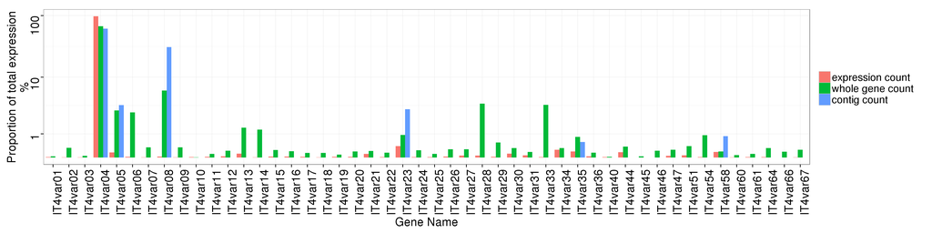

```r
cs2_df <- merge(var_expressions_mike, CS2_read_counts, by='var.name')
cs2_df <- cs2_df[,!(names(cs2_df) %in% c('ECS','EIC'))]
cs2_df$counts <- cs2_df$counts/sum(cs2_df$counts)
cs2_df$CS2 <- cs2_df$CS2/sum(cs2_df$CS2)
cs2_df <- merge(cs2_df, contig_counts, all.x=TRUE, by='var.name')
cs2_df$contig.count[is.na(cs2_df$contig.count)] <- 0
cs2_df$contig.count <- cs2_df$contig.count/sum(cs2_df$contig.count)
names(cs2_df) <- c('Rask_name','Expression_name','expression count','whole gene count','contig count')
cs2_df2 <- melt(cs2_df, id=c('Rask_name','Expression_name'))
#cs2_df2$value[1000*cs2_df2$value < 1] <- 1/1000
cs2 <- ggplot(cs2_df2, aes(Rask_name, fill=factor(variable), weight=100*value)) + geom_bar(position="dodge")
cs2 <- cs2 + scale_y_continuous(limits=c(0,NA))
cs2 <- cs2 + mybartheme() + scale_y_continuous(trans = 'asinh', breaks=c(1,10,100))
cs2 <- cs2 + ylab("Proportion of total expression\n%") + xlab("Gene Name")
cs2
```

Lets look at a plot of the contigs for EIC As their was a higher rate of similarities in EIC I’ve upped the similarity threshold to 97%

```r
contig_counts <- plot_contigs(EIC_processed_contigs, 800, 97, var_gene_lengths)
```

[figure not shown]

Redundancy

```r
redundancy(EIC_processed_contigs, 800, var_gene_lengths, 95)
```

```
## [1] 1.003612
```

plot expression for EIC

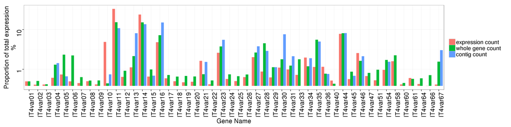

```r
eic_df <- merge(var_expressions_mike, EIC_read_counts, by='var.name')
eic_df <- eic_df[,!(names(eic_df) %in% c('ECS','CS2'))]
eic_df$counts <- eic_df$counts/sum(eic_df$counts)
eic_df$EIC <- eic_df$EIC/sum(eic_df$EIC)
eic_df <- merge(eic_df, contig_counts, all.x=TRUE, by='var.name')
eic_df$contig.count[is.na(eic_df$contig.count)] <- 0
eic_df$contig.count <- eic_df$contig.count/sum(eic_df$contig.count)
names(eic_df) <- c('Rask_name','Expression_name','expression count','whole gene count','contig count')
eic_df2 <- melt(eic_df, id=c('Rask_name','Expression_name'))
# eic_df2$value[1000*eic_df2$value < 1] <- 1/1000
eic <- ggplot(eic_df2, aes(Rask_name, fill=factor(variable), weight=100*value)) + geom_bar(position="dodge")
eic <- eic + scale_y_continuous(limits=c(0,NA))
eic <- eic + mybartheme() + scale_y_continuous(trans = 'asinh', breaks=c(1,10,100))
eic <- eic + ylab("Proportion of total expression\n%") + xlab("Gene Name")
eic
```

Now we calculate some summary statistics for this comparison. First the number of IT4var genes found and the total found by qPCR above 1e-3.

```r
countQPCRExpressed <- sum(eic_df$'expression count'>1e-3)
countContigExpressed <- sum(eic_df$'contig count'>0)
```

A total of 44 were found above a threshold of $1e-3$ by qPCR. After assembly a total of 27 genes were identified.

Now we look at the overall similarity of coverage. This is rather sensitive to single genes with large differences in exression profiles between the methods.

```r
qPCR <- eic_df$'expression count'
qPCR[qPCR<1e-3] <- 0
contig <- eic_df$'contig count'
```

The mean percentage difference in expression profiles is 1.6217667